# 03 Get Market Data

These are the most recent set releases:

Crown Zenith,CRZ,1/20/2023 Silver Tempest,SIT,11/11/2022 Lost Origin,LOR,9/9/2022

Choosing the top ten cards from each set with the highest market value. This will also include the trainer gallery cards. I will also choose to view the data for each up to three months after the set release date. The following were chose on 2/7/2023 for their market value at that time:

### Crown Zenith

1. Giratina VSTAR (Secret) - Crown Zenith: Galarian Gallery (CRZ:GG)
   - ID 478100
2. Arceus VSTAR (Secret) - Crown Zenith: Galarian Gallery (CRZ:GG)
   - ID 478101
3. Mewtwo VSTAR - Crown Zenith: Galarian Gallery (CRZ:GG)
   - ID 477057
4. Origin Forme Dialga VSTAR (Secret) - Crown Zenith: Galarian Gallery (CRZ:GG)
   - ID 478099
5. Origin Forme Palkia VSTAR (Secret) - Crown Zenith: Galarian Gallery (CRZ:GG)
   - ID 478097
6. Leafeon VSTAR - Crown Zenith: Galarian Gallery (CRZ:GG)
   - ID 477060
7. Glaceon VSTAR - Crown Zenith: Galarian Gallery (CRZ:GG)
   - ID 477061
8. Suicune V - Crown Zenith: Galarian Gallery (CRZ:GG)
   - ID 478067
9. Elesa's Sparkle (Full Art) - Crown Zenith (CRZ)
   - ID 477241
10. Pikachu (Secret) - Crown Zenith (CRZ)
    - ID 478103

### Silver Tempest

1. Lugia V (Alternate Full Art) - SWSH12: Silver Tempest (SWSH12)
   - ID 451834
2. Rayquaza VMAX - SWSH12: Silver Tempest Trainer Gallery (SWSH12: TG)
   - ID 452034
3. Unown V (Alternate Full Art) - SWSH12: Silver Tempest (SWSH12)
   - ID 451825
4. Serena (Full Art) - SWSH12: Silver Tempest (SWSH12)
   - ID 451841
5. Lugia VSTAR (Secret) (202) - SWSH12: Silver Tempest (SWSH12)
   - ID 451995
6. Regidrago V (Alternate Full Art) - SWSH12: Silver Tempest (SWSH12)
   - ID 451832
7. Lugia VSTAR (Secret) (211) - SWSH12: Silver Tempest (SWSH12)
   - ID 452009
8. Alolan Vulpix VSTAR (Secret) - SWSH12: Silver Tempest (SWSH12)
   - ID 451987
9. Skuntank V (Alternate Full Art) - SWSH12: Silver Tempest (SWSH12)
   - ID 451829
10. Friends in Galar - SWSH12: Silver Tempest Trainer Gallery (SWSH12: TG)
    - ID 452039

### Lost Origin

1. Giratina V (Alternate Full Art) - SWSH11: Lost Origin (SWSH11)
   - ID 284137
2. Aerodactyl V (Alternate Full Art) - SWSH11: Lost Origin (SWSH11)
   - ID 284122
3. Pikachu VMAX - SWSH11: Lost Origin Trainer Gallery (SWSH11: TG)
   - ID 284283
4. Rotom V (Alternate Full Art) - SWSH11: Lost Origin (SWSH11)
   - ID 284119
5. Galarian Perrserker V (Alternate Full Art) - SWSH11: Lost Origin (SWSH11)
   - ID 284135
6. Pikachu V - SWSH11: Lost Origin Trainer Gallery (SWSH11: TG)
   - ID 284278
7. Giratina VSTAR (201) (Secret) - SWSH11: Lost Origin (SWSH11)
   - ID 284156
8. Giratina VSTAR (212) (Secret) - SWSH11: Lost Origin (SWSH11)
   - ID 284167
9. Eternatus VMAX - SWSH11: Lost Origin Trainer Gallery (SWSH11: TG)
   - ID 284295
10. Aerodactyl VSTAR (Secret) - SWSH11: Lost Origin (SWSH11)
    - ID 284154

```python
# Get a list of all the card information. I chose card name, card ID, and the set:
CardList = [['Giratina VSTAR (Secret) - Crown Zenith: Galarian Gallery (CRZ:GG)',478100,'Crown Zenith'],
            ['Arceus VSTAR (Secret) - Crown Zenith: Galarian Gallery (CRZ:GG)',478101,'Crown Zenith'],
            ['Mewtwo VSTAR - Crown Zenith: Galarian Gallery (CRZ:GG)',477057,'Crown Zenith'],
            ['Origin Forme Dialga VSTAR (Secret) - Crown Zenith: Galarian Gallery (CRZ:GG)',478099,'Crown Zenith'],
            ['Origin Forme Palkia VSTAR (Secret) - Crown Zenith: Galarian Gallery (CRZ:GG)',478097,'Crown Zenith'],
            ['Leafeon VSTAR - Crown Zenith: Galarian Gallery (CRZ:GG)',477060,'Crown Zenith'],
            ['Glaceon VSTAR - Crown Zenith: Galarian Gallery (CRZ:GG)',477061,'Crown Zenith'],
            ['Suicune V - Crown Zenith: Galarian Gallery (CRZ:GG)',478067,'Crown Zenith'],
            ['Elesas Sparkle (Full Art) - Crown Zenith (CRZ)',477241,'Crown Zenith'],
            ['Pikachu (Secret) - Crown Zenith (CRZ)',478103,'Crown Zenith'],
            ['Lugia V (Alternate Full Art) - SWSH12: Silver Tempest (SWSH12)',451834,'Silver Tempest'],
            ['Rayquaza VMAX - SWSH12: Silver Tempest Trainer Gallery (SWSH12: TG)',452034,'Silver Tempest'],
            ['Unown V (Alternate Full Art) - SWSH12: Silver Tempest (SWSH12)',451825,'Silver Tempest'],
            ['Serena (Full Art) - SWSH12: Silver Tempest (SWSH12)',451841,'Silver Tempest'],
            ['Lugia VSTAR (Secret) (202) - SWSH12: Silver Tempest (SWSH12)',451995,'Silver Tempest'],
            ['Regidrago V (Alternate Full Art) - SWSH12: Silver Tempest (SWSH12)',451832,'Silver Tempest'],
            ['Lugia VSTAR (Secret) (211) - SWSH12: Silver Tempest (SWSH12)',452009,'Silver Tempest'],
            ['Alolan Vulpix VSTAR (Secret) - SWSH12: Silver Tempest (SWSH12)',451987,'Silver Tempest'],
            ['Skuntank V (Alternate Full Art) - SWSH12: Silver Tempest (SWSH12)',451829,'Silver Tempest'],
            ['Friends in Galar - SWSH12: Silver Tempest Trainer Gallery (SWSH12: TG)',452039,'Silver Tempest'],
            ['iratina V (Alternate Full Art) - SWSH11: Lost Origin (SWSH11)',284137,'Lost Origin'],
            ['Aerodactyl V (Alternate Full Art) - SWSH11: Lost Origin (SWSH11)',284122,'Lost Origin'],
            ['Pikachu VMAX - SWSH11: Lost Origin Trainer Gallery (SWSH11: TG)',284283,'Lost Origin'],
            ['Rotom V (Alternate Full Art) - SWSH11: Lost Origin (SWSH11)',284119,'Lost Origin'],
            ['Galarian Perrserker V (Alternate Full Art) - SWSH11: Lost Origin (SWSH11)',284135,'Lost Origin'],
            ['Pikachu V - SWSH11: Lost Origin Trainer Gallery (SWSH11: TG)',284278,'Lost Origin'],
            ['Giratina VSTAR (201) (Secret) - SWSH11: Lost Origin (SWSH11)',284156,'Lost Origin'],
            ['Giratina VSTAR (212) (Secret) - SWSH11: Lost Origin (SWSH11)',284167,'Lost Origin'],
            ['Eternatus VMAX - SWSH11: Lost Origin Trainer Gallery (SWSH11: TG)',284295,'Lost Origin'],
            ['Aerodactyl VSTAR (Secret) - SWSH11: Lost Origin (SWSH11)',284154,'Lost Origin']]
```

```python
print('Example to view the set: ' + CardList[0][2])
```

```
Example to view the set: Crown Zenith
```

```python
print('Example to view the card ID: ' + str(CardList[0][1]))
```

```
Example to view the card ID: 478100
```

The list above will be used when gathering card rates for standard cards. I did not include Promo cards (card provided in promotions such as special events) in the data I will be pulling. The main reason for this is because Promo cards obtained through events or special packs where there is a 100% chance of the card being obtained. I will, however, use the original card from '01 TCGPlayer Data Exploration' for tutorial consistency. I also really like the artwork and the price of the card/popularity of the Pokemon as been around the same for a while.

```python
import requests as r
import json
import time
import datetime
import matplotlib.pyplot as plt
import pandas as pd
from pandas.io.json import json_normalize

#url to post
action_postURL = 'https://infinite-api.tcgplayer.com/price/history/271837?range=annual'

#get data from that URL
res = r.get(action_postURL)

#put the data coming in from res into values as json
values = res.json()
```

```python
#clean out any days that have no cards on the market
NumberOfDays= values['count']
dates = []
marketPrice = []
quantity = []
i = 0
while i < NumberOfDays:
    if int(values['result'][i]['variants'][0]['quantity']) > 0:
        dates.append(datetime.datetime.strptime(values['result'][i]['date'], '%Y-%m-%d'))
        marketPrice.append(float(values['result'][i]['variants'][0]['marketPrice']))
        quantity.append(int(values['result'][i]['variants'][0]['quantity']))
    i = i + 1
```

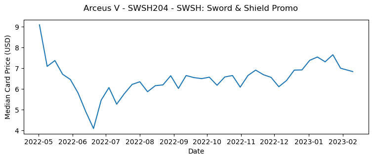

```python
#final results, most recent date:
plt.figure(figsize=(9, 3))
plt.suptitle('Arceus V - SWSH204 - SWSH: Sword & Shield Promo')
plt.xlabel("Date")
plt.ylabel("Median Card Price (USD)")
plt.plot(dates,marketPrice)
```

Chart from TCGPlayer:

[figure not shown]

After ploting the results from the data I scraped together with what was shown in the graph, it is safe to assume my data is valid.